# S9_Informe

### Resultados de la hipótesis 1

- Estadístico de prueba : -7.636516
- Valor crítico: -1.65543
- p-valor: 1.381e-12
- Prueba de hipótesis: Unilateral
- Precisión: 0.4543433

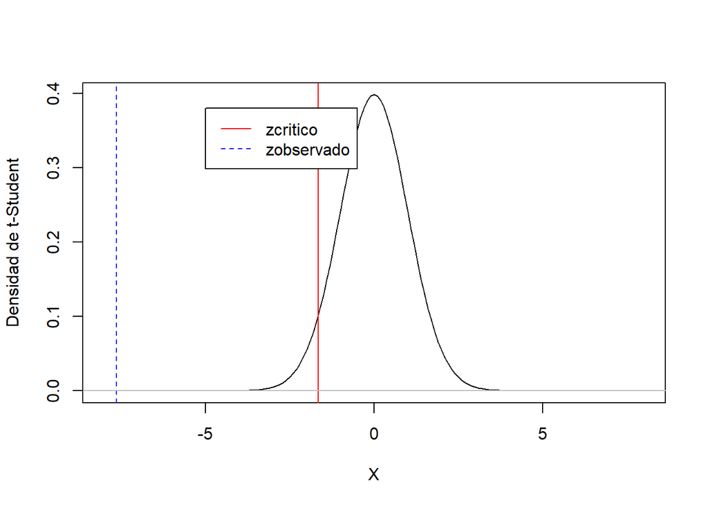

**Observaciones**

- El punto a partir del cual se determina si se tiene una población joven es la edad de 21 años.
- Aplicando la prueba de t de Student encontramos que el z crítico > z observado y **pvalue < significancia**. Lo que significa que el z observado cayó en la zona de rechazo. Por lo tanto, para un nivel de confianza del 95%, **se rechaza la hipótesis nula**.

### Hipótesis 2: La población de K-pop tiene un gasto mensual elevado en su recurrencia a restaurantes.

La variable a analizar es: “Inversión”

```
##    Min. 1st Qu.  Median    Mean 3rd Qu.    Max.
##     1.1    44.0    66.0   116.3   165.0   550.0
```

**Observaciones**

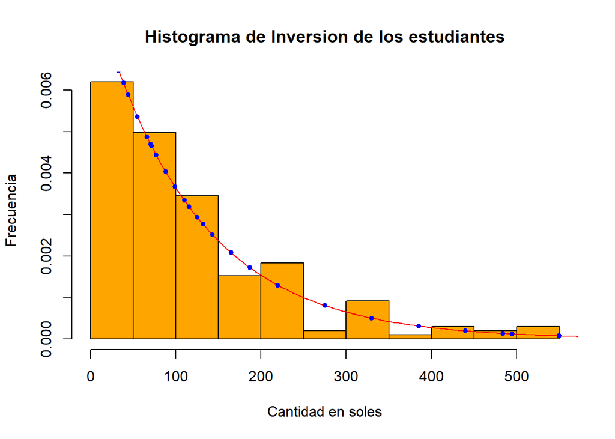

**Observaciones**

- A partir del histograma observamos que hay menos personas que gastan mensualmente una elevada cantidad de dinero en comparación con las personas que gastan poco, esto se aprecia gracias al sesgo hacia la derecha que presenta el histograma.
- El histograma de nuestra muestra tiene un alto nivel de parecido a una distribución exponencial con un lambda igual a 0.0086.
- La tendencia de la variable inversión podría seguir un comportamiento exponencial. Eso se explicaría ya que el grupo de personas que gastan mucho dinero al ir a un restaurante en un mes es mínimo.

### Parámetros de la hipótesis 2

- Variable: Inversión
- Prueba de hipótesis: Unilateral
- Estimador puntual: media
- Modelo: t-Student
- **Ho**= El gasto mensual en restaurante es menor o igual a 66 soles.
- **Ha**= El gasto mensual en restaurante es mayor a 66 soles.

H0:μ ≤ 66 soles

Ha:μ > 66 soles